# Risk Factor Analysis

## Outcome Variable

**Outcome Variable:** haz

## Predictor Variables

**Intervention Variable:** brthmon

**Adjustment Set:**

unadjusted

## Stratifying Variables

The analysis was stratified on these variable(s):

- agecat
- studyid
- country

## Data Summary

| agecat | studyid | country | brthmon | n_cell | n |
| --- | --- | --- | --- | --- | --- |
| Birth | ki0047075b-MAL-ED | BANGLADESH | 1 | 20 | 257 |
| Birth | ki0047075b-MAL-ED | BANGLADESH | 2 | 25 | 257 |
| Birth | ki0047075b-MAL-ED | BANGLADESH | 3 | 25 | 257 |
| Birth | ki0047075b-MAL-ED | BANGLADESH | 4 | 21 | 257 |
| Birth | ki0047075b-MAL-ED | BANGLADESH | 5 | 21 | 257 |
| Birth | ki0047075b-MAL-ED | BANGLADESH | 6 | 11 | 257 |
| Birth | ki0047075b-MAL-ED | BANGLADESH | 7 | 20 | 257 |
| Birth | ki0047075b-MAL-ED | BANGLADESH | 8 | 26 | 257 |
| Birth | ki0047075b-MAL-ED | BANGLADESH | 9 | 21 | 257 |
| Birth | ki0047075b-MAL-ED | BANGLADESH | 10 | 25 | 257 |
| Birth | ki0047075b-MAL-ED | BANGLADESH | 11 | 15 | 257 |
| Birth | ki0047075b-MAL-ED | BANGLADESH | 12 | 27 | 257 |
| Birth | ki0047075b-MAL-ED | BRAZIL | 1 | 11 | 191 |
| Birth | ki0047075b-MAL-ED | BRAZIL | 2 | 19 | 191 |
| Birth | ki0047075b-MAL-ED | BRAZIL | 3 | 18 | 191 |
| Birth | ki0047075b-MAL-ED | BRAZIL | 4 | 9 | 191 |
| Birth | ki0047075b-MAL-ED | BRAZIL | 5 | 18 | 191 |
| Birth | ki0047075b-MAL-ED | BRAZIL | 6 | 8 | 191 |
| Birth | ki0047075b-MAL-ED | BRAZIL | 7 | 16 | 191 |
| Birth | ki0047075b-MAL-ED | BRAZIL | 8 | 18 | 191 |
| Birth | ki0047075b-MAL-ED | BRAZIL | 9 | 29 | 191 |
| Birth | ki0047075b-MAL-ED | BRAZIL | 10 | 17 | 191 |
| Birth | ki0047075b-MAL-ED | BRAZIL | 11 | 18 | 191 |
| Birth | ki0047075b-MAL-ED | BRAZIL | 12 | 10 | 191 |
| Birth | ki0047075b-MAL-ED | INDIA | 1 | 16 | 206 |
| Birth | ki0047075b-MAL-ED | INDIA | 2 | 16 | 206 |
| Birth | ki0047075b-MAL-ED | INDIA | 3 | 21 | 206 |
| Birth | ki0047075b-MAL-ED | INDIA | 4 | 14 | 206 |
| Birth | ki0047075b-MAL-ED | INDIA | 5 | 7 | 206 |
| Birth | ki0047075b-MAL-ED | INDIA | 6 | 18 | 206 |

[output cut: 834 more lines]

The following strata were considered:

- agecat: 24 months, studyid: ki0047075b-MAL-ED, country: BANGLADESH
- agecat: 24 months, studyid: ki0047075b-MAL-ED, country: BRAZIL
- agecat: 24 months, studyid: ki0047075b-MAL-ED, country: INDIA
- agecat: 24 months, studyid: ki0047075b-MAL-ED, country: NEPAL
- agecat: 24 months, studyid: ki0047075b-MAL-ED, country: PERU
- agecat: 24 months, studyid: ki0047075b-MAL-ED, country: SOUTH AFRICA
- agecat: 24 months, studyid: ki0047075b-MAL-ED, country: TANZANIA, UNITED REPUBLIC OF
- agecat: 24 months, studyid: ki1000108-CMC-V-BCS-2002, country: INDIA
- agecat: 24 months, studyid: ki1000108-IRC, country: INDIA
- agecat: 24 months, studyid: ki1017093-NIH-Birth, country: BANGLADESH
- agecat: 24 months, studyid: ki1066203-TanzaniaChild2, country: TANZANIA, UNITED REPUBLIC OF
- agecat: 24 months, studyid: ki1101329-Keneba, country: GAMBIA
- agecat: 24 months, studyid: ki1113344-GMS-Nepal, country: NEPAL
- agecat: 24 months, studyid: ki1114097-CMIN, country: BANGLADESH
- agecat: 24 months, studyid: ki1114097-CMIN, country: GUINEA-BISSAU
- agecat: 24 months, studyid: ki1114097-CMIN, country: PERU
- agecat: 24 months, studyid: ki1114097-CONTENT, country: PERU
- agecat: 24 months, studyid: ki1119695-PROBIT, country: BELARUS
- agecat: 24 months, studyid: ki1126311-ZVITAMBO, country: ZIMBABWE
- agecat: 24 months, studyid: ki1148112-LCNI-5, country: MALAWI
- agecat: 24 months, studyid: kiGH5241-JiVitA-3, country: BANGLADESH
- agecat: 24 months, studyid: kiGH5241-JiVitA-4, country: BANGLADESH
- agecat: 6 months, studyid: ki0047075b-MAL-ED, country: BANGLADESH
- agecat: 6 months, studyid: ki0047075b-MAL-ED, country: BRAZIL
- agecat: 6 months, studyid: ki0047075b-MAL-ED, country: INDIA
- agecat: 6 months, studyid: ki0047075b-MAL-ED, country: NEPAL
- agecat: 6 months, studyid: ki0047075b-MAL-ED, country: PERU
- agecat: 6 months, studyid: ki0047075b-MAL-ED, country: SOUTH AFRICA
- agecat: 6 months, studyid: ki0047075b-MAL-ED, country: TANZANIA, UNITED REPUBLIC OF
- agecat: 6 months, studyid: ki1000108-CMC-V-BCS-2002, country: INDIA
- agecat: 6 months, studyid: ki1000108-IRC, country: INDIA
- agecat: 6 months, studyid: ki1000109-EE, country: PAKISTAN
- agecat: 6 months, studyid: ki1000109-ResPak, country: PAKISTAN
- agecat: 6 months, studyid: ki1000304b-SAS-CompFeed, country: INDIA
- agecat: 6 months, studyid: ki1000304b-SAS-FoodSuppl, country: INDIA
- agecat: 6 months, studyid: ki1017093-NIH-Birth, country: BANGLADESH
- agecat: 6 months, studyid: ki1066203-TanzaniaChild2, country: TANZANIA, UNITED REPUBLIC OF
- agecat: 6 months, studyid: ki1101329-Keneba, country: GAMBIA
- agecat: 6 months, studyid: ki1112895-Guatemala BSC, country: GUATEMALA
- agecat: 6 months, studyid: ki1113344-GMS-Nepal, country: NEPAL
- agecat: 6 months, studyid: ki1114097-CMIN, country: BANGLADESH
- agecat: 6 months, studyid: ki1114097-CMIN, country: BRAZIL
- agecat: 6 months, studyid: ki1114097-CMIN, country: GUINEA-BISSAU
- agecat: 6 months, studyid: ki1114097-CMIN, country: PERU
- agecat: 6 months, studyid: ki1114097-CONTENT, country: PERU
- agecat: 6 months, studyid: ki1119695-PROBIT, country: BELARUS
- agecat: 6 months, studyid: ki1126311-ZVITAMBO, country: ZIMBABWE
- agecat: 6 months, studyid: ki1148112-LCNI-5, country: MALAWI
- agecat: 6 months, studyid: kiGH5241-JiVitA-3, country: BANGLADESH
- agecat: 6 months, studyid: kiGH5241-JiVitA-4, country: BANGLADESH
- agecat: Birth, studyid: ki0047075b-MAL-ED, country: BANGLADESH
- agecat: Birth, studyid: ki0047075b-MAL-ED, country: BRAZIL
- agecat: Birth, studyid: ki0047075b-MAL-ED, country: INDIA
- agecat: Birth, studyid: ki0047075b-MAL-ED, country: NEPAL
- agecat: Birth, studyid: ki0047075b-MAL-ED, country: PERU
- agecat: Birth, studyid: ki0047075b-MAL-ED, country: SOUTH AFRICA
- agecat: Birth, studyid: ki0047075b-MAL-ED, country: TANZANIA, UNITED REPUBLIC OF
- agecat: Birth, studyid: ki1000108-CMC-V-BCS-2002, country: INDIA
- agecat: Birth, studyid: ki1000108-IRC, country: INDIA
- agecat: Birth, studyid: ki1000109-EE, country: PAKISTAN
- agecat: Birth, studyid: ki1000109-ResPak, country: PAKISTAN
- agecat: Birth, studyid: ki1000304b-SAS-CompFeed, country: INDIA
- agecat: Birth, studyid: ki1017093-NIH-Birth, country: BANGLADESH
- agecat: Birth, studyid: ki1101329-Keneba, country: GAMBIA
- agecat: Birth, studyid: ki1114097-CMIN, country: BANGLADESH
- agecat: Birth, studyid: ki1114097-CMIN, country: BRAZIL
- agecat: Birth, studyid: ki1114097-CMIN, country: PERU
- agecat: Birth, studyid: ki1114097-CONTENT, country: PERU
- agecat: Birth, studyid: ki1119695-PROBIT, country: BELARUS
- agecat: Birth, studyid: ki1126311-ZVITAMBO, country: ZIMBABWE
- agecat: Birth, studyid: kiGH5241-JiVitA-3, country: BANGLADESH
- agecat: Birth, studyid: kiGH5241-JiVitA-4, country: BANGLADESH

### Dropped Strata

Some strata were dropped due to rare outcomes:

- agecat: Birth, studyid: ki0047075b-MAL-ED, country: TANZANIA, UNITED REPUBLIC OF
- agecat: Birth, studyid: ki1000108-CMC-V-BCS-2002, country: INDIA
- agecat: Birth, studyid: ki1000109-EE, country: PAKISTAN
- agecat: Birth, studyid: ki1000109-ResPak, country: PAKISTAN
- agecat: Birth, studyid: ki1017093-NIH-Birth, country: BANGLADESH
- agecat: Birth, studyid: ki1114097-CMIN, country: BANGLADESH
- agecat: Birth, studyid: ki1114097-CMIN, country: BRAZIL
- agecat: Birth, studyid: ki1114097-CMIN, country: PERU
- agecat: Birth, studyid: ki1114097-CONTENT, country: PERU
- agecat: Birth, studyid: kiGH5241-JiVitA-4, country: BANGLADESH
- agecat: 6 months, studyid: ki1000109-EE, country: PAKISTAN
- agecat: 6 months, studyid: ki1000109-ResPak, country: PAKISTAN
- agecat: 6 months, studyid: ki1000304b-SAS-FoodSuppl, country: INDIA
- agecat: 6 months, studyid: ki1113344-GMS-Nepal, country: NEPAL
- agecat: 6 months, studyid: ki1114097-CMIN, country: BRAZIL
- agecat: 6 months, studyid: kiGH5241-JiVitA-4, country: BANGLADESH
- agecat: 24 months, studyid: ki1066203-TanzaniaChild2, country: TANZANIA, UNITED REPUBLIC OF
- agecat: 24 months, studyid: ki1113344-GMS-Nepal, country: NEPAL
- agecat: 24 months, studyid: ki1126311-ZVITAMBO, country: ZIMBABWE
- agecat: 24 months, studyid: kiGH5241-JiVitA-4, country: BANGLADESH

## Methods Detail

We’re interested in the causal parameters $E[Y_a]$ for all values of $a \in \mathcal{A}$. These parameters represent the mean outcome if, possibly contrary to fact, we intervened to set all units to have $A=a$. Under the randomization and positivity assumptions, these are identified by the statistical parameters $\psi_a=E_W[E_{Y|A,W}(Y|A=a,W)]$. In addition, we’re interested in the mean of $Y$, $E[Y]$ under no intervention (the observed mean). We will estimate these parameters by using SuperLearner to fit the relevant likelihood factors – $E_{Y|A,W}(Y|A=a,W)$ and $p(A=a|W)$, and then updating our likelihood fit using a joint TMLE.

For unadjusted analyses ($W=\{\}$), initial likelihoods were estimated using Lrnr_glm to estimate the simple $E(Y|A)$ and Lrnr_mean to estimate $p(A)$. For adjusted analyses, a small library containing Lrnr_glmnet, Lrnr_xgboost, and Lrnr_mean was used.

Having estimated these parameters, we will then use the delta method to estimate relative risks and attributable risks relative to a prespecified baseline level of $A$.

# Results Detail

## Results Plots

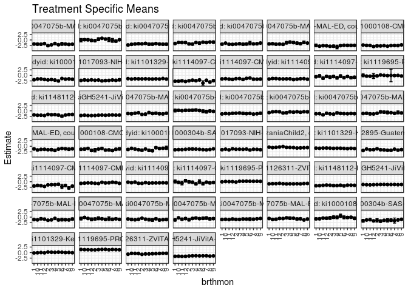

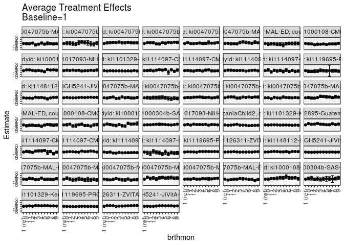

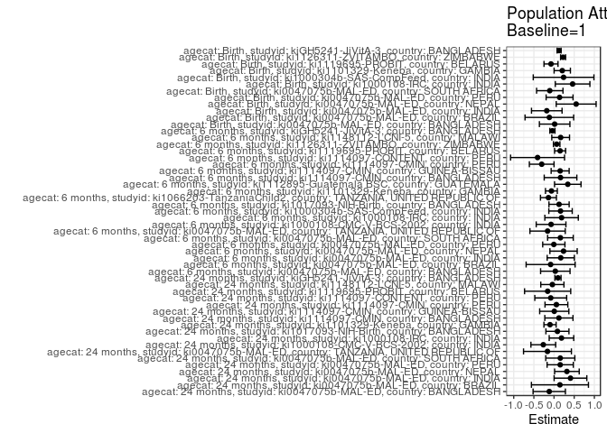

## Results Table

### Parameter: TSM

| agecat | studyid | country | intervention_level | baseline_level | estimate | ci_lower | ci_upper |
| --- | --- | --- | --- | --- | --- | --- | --- |
| Birth | ki0047075b-MAL-ED | BANGLADESH | 1 | NA | -1.0995000 | -1.4876016 | -0.7113984 |
| Birth | ki0047075b-MAL-ED | BANGLADESH | 2 | NA | -1.3764000 | -1.7597941 | -0.9930059 |
| Birth | ki0047075b-MAL-ED | BANGLADESH | 3 | NA | -1.2376000 | -1.6209335 | -0.8542665 |
| Birth | ki0047075b-MAL-ED | BANGLADESH | 4 | NA | -0.5585714 | -0.9151477 | -0.2019951 |
| Birth | ki0047075b-MAL-ED | BANGLADESH | 5 | NA | -1.2638095 | -1.7343025 | -0.7933165 |
| Birth | ki0047075b-MAL-ED | BANGLADESH | 6 | NA | -1.1490909 | -1.7262496 | -0.5719322 |
| Birth | ki0047075b-MAL-ED | BANGLADESH | 7 | NA | -1.1920000 | -1.6774523 | -0.7065477 |
| Birth | ki0047075b-MAL-ED | BANGLADESH | 8 | NA | -1.2623077 | -1.6681063 | -0.8565091 |
| Birth | ki0047075b-MAL-ED | BANGLADESH | 9 | NA | -0.8514286 | -1.3488676 | -0.3539895 |
| Birth | ki0047075b-MAL-ED | BANGLADESH | 10 | NA | -1.2260000 | -1.5526157 | -0.8993843 |
| Birth | ki0047075b-MAL-ED | BANGLADESH | 11 | NA | -0.7220000 | -1.2148381 | -0.2291619 |
| Birth | ki0047075b-MAL-ED | BANGLADESH | 12 | NA | -0.9044444 | -1.2968306 | -0.5120583 |
| Birth | ki0047075b-MAL-ED | BRAZIL | 1 | NA | -0.6445455 | -1.2634032 | -0.0256877 |
| Birth | ki0047075b-MAL-ED | BRAZIL | 2 | NA | -0.8368421 | -1.3653274 | -0.3083568 |
| Birth | ki0047075b-MAL-ED | BRAZIL | 3 | NA | -0.5272222 | -1.2230115 | 0.1685671 |
| Birth | ki0047075b-MAL-ED | BRAZIL | 4 | NA | -0.7366667 | -1.1794411 | -0.2938922 |
| Birth | ki0047075b-MAL-ED | BRAZIL | 5 | NA | -1.0266667 | -1.5215784 | -0.5317550 |
| Birth | ki0047075b-MAL-ED | BRAZIL | 6 | NA | -0.7212500 | -1.5954808 | 0.1529808 |
| Birth | ki0047075b-MAL-ED | BRAZIL | 7 | NA | -0.9800000 | -1.5626471 | -0.3973529 |
| Birth | ki0047075b-MAL-ED | BRAZIL | 8 | NA | -0.7588889 | -1.2002827 | -0.3174951 |
| Birth | ki0047075b-MAL-ED | BRAZIL | 9 | NA | -1.0293103 | -1.3908171 | -0.6678035 |
| Birth | ki0047075b-MAL-ED | BRAZIL | 10 | NA | -0.1235294 | -0.5638021 | 0.3167432 |
| Birth | ki0047075b-MAL-ED | BRAZIL | 11 | NA | -0.5916667 | -0.9215690 | -0.2617644 |
| Birth | ki0047075b-MAL-ED | BRAZIL | 12 | NA | -1.0040000 | -1.6880926 | -0.3199074 |
| Birth | ki0047075b-MAL-ED | INDIA | 1 | NA | -0.8306250 | -1.2139987 | -0.4472513 |
| Birth | ki0047075b-MAL-ED | INDIA | 2 | NA | -0.4887500 | -0.7928032 | -0.1846968 |
| Birth | ki0047075b-MAL-ED | INDIA | 3 | NA | -0.9019048 | -1.2741017 | -0.5297079 |
| Birth | ki0047075b-MAL-ED | INDIA | 4 | NA | -1.1457143 | -1.7341149 | -0.5573137 |
| Birth | ki0047075b-MAL-ED | INDIA | 5 | NA | -1.2728571 | -1.8997755 | -0.6459388 |
| Birth | ki0047075b-MAL-ED | INDIA | 6 | NA | -0.7444444 | -1.1726110 | -0.3162779 |

[output cut: 594 more lines]

### Parameter: E(Y)

| agecat | studyid | country | intervention_level | baseline_level | estimate | ci_lower | ci_upper |
| --- | --- | --- | --- | --- | --- | --- | --- |
| Birth | ki0047075b-MAL-ED | BANGLADESH | NA | NA | -1.0843969 | -1.2100768 | -0.9587169 |
| Birth | ki0047075b-MAL-ED | BRAZIL | NA | NA | -0.7609424 | -0.9178311 | -0.6040538 |
| Birth | ki0047075b-MAL-ED | INDIA | NA | NA | -1.0106311 | -1.1499962 | -0.8712660 |
| Birth | ki0047075b-MAL-ED | NEPAL | NA | NA | -0.7089017 | -0.8656064 | -0.5521971 |
| Birth | ki0047075b-MAL-ED | PERU | NA | NA | -0.9322300 | -1.0461262 | -0.8183337 |
| Birth | ki0047075b-MAL-ED | SOUTH AFRICA | NA | NA | -0.7266031 | -0.8549719 | -0.5982342 |
| Birth | ki1000108-IRC | INDIA | NA | NA | -0.3080412 | -0.4687931 | -0.1472894 |
| Birth | ki1000304b-SAS-CompFeed | INDIA | NA | NA | -1.3946524 | -1.5833612 | -1.2059436 |
| Birth | ki1101329-Keneba | GAMBIA | NA | NA | 0.0341467 | -0.0293905 | 0.0976838 |
| Birth | ki1119695-PROBIT | BELARUS | NA | NA | 1.3254775 | 1.1669293 | 1.4840258 |
| Birth | ki1126311-ZVITAMBO | ZIMBABWE | NA | NA | -0.5009660 | -0.5215391 | -0.4803930 |
| Birth | kiGH5241-JiVitA-3 | BANGLADESH | NA | NA | -1.5747407 | -1.5944667 | -1.5550147 |
| 6 months | ki0047075b-MAL-ED | BANGLADESH | NA | NA | -1.2056777 | -1.3231497 | -1.0882058 |
| 6 months | ki0047075b-MAL-ED | BRAZIL | NA | NA | 0.0510207 | -0.0930194 | 0.1950608 |
| 6 months | ki0047075b-MAL-ED | INDIA | NA | NA | -1.2203672 | -1.3387619 | -1.1019726 |
| 6 months | ki0047075b-MAL-ED | NEPAL | NA | NA | -0.5610593 | -0.6737915 | -0.4483272 |
| 6 months | ki0047075b-MAL-ED | PERU | NA | NA | -1.3268010 | -1.4351217 | -1.2184802 |
| 6 months | ki0047075b-MAL-ED | SOUTH AFRICA | NA | NA | -1.0633760 | -1.1911088 | -0.9356432 |
| 6 months | ki0047075b-MAL-ED | TANZANIA, UNITED REPUBLIC OF | NA | NA | -1.3601215 | -1.4821830 | -1.2380600 |
| 6 months | ki1000108-CMC-V-BCS-2002 | INDIA | NA | NA | -1.4234508 | -1.5645974 | -1.2823042 |
| 6 months | ki1000108-IRC | INDIA | NA | NA | -1.2344062 | -1.3658524 | -1.1029600 |
| 6 months | ki1000304b-SAS-CompFeed | INDIA | NA | NA | -1.4018563 | -1.4810585 | -1.3226541 |
| 6 months | ki1017093-NIH-Birth | BANGLADESH | NA | NA | -1.4073821 | -1.4960598 | -1.3187043 |
| 6 months | ki1066203-TanzaniaChild2 | TANZANIA, UNITED REPUBLIC OF | NA | NA | -0.5434389 | -0.5924056 | -0.4944722 |
| 6 months | ki1101329-Keneba | GAMBIA | NA | NA | -0.9041369 | -0.9513363 | -0.8569376 |
| 6 months | ki1112895-Guatemala BSC | GUATEMALA | NA | NA | -1.5619008 | -1.6727702 | -1.4510313 |
| 6 months | ki1114097-CMIN | BANGLADESH | NA | NA | -1.7844376 | -1.9222926 | -1.6465825 |
| 6 months | ki1114097-CMIN | GUINEA-BISSAU | NA | NA | -0.6075943 | -0.6832781 | -0.5319106 |
| 6 months | ki1114097-CMIN | PERU | NA | NA | -0.5132548 | -0.5926717 | -0.4338380 |
| 6 months | ki1114097-CONTENT | PERU | NA | NA | -0.3139217 | -0.4868486 | -0.1409948 |
| 6 months | ki1119695-PROBIT | BELARUS | NA | NA | 0.1069986 | 0.0122286 | 0.2017686 |
| 6 months | ki1126311-ZVITAMBO | ZIMBABWE | NA | NA | -0.8907480 | -0.9167182 | -0.8647779 |
| 6 months | ki1148112-LCNI-5 | MALAWI | NA | NA | -1.6601907 | -1.7297701 | -1.5906113 |
| 6 months | kiGH5241-JiVitA-3 | BANGLADESH | NA | NA | -1.3130932 | -1.3362359 | -1.2899505 |
| 24 months | ki0047075b-MAL-ED | BANGLADESH | NA | NA | -1.9431132 | -2.0691678 | -1.8170586 |
| 24 months | ki0047075b-MAL-ED | BRAZIL | NA | NA | 0.0418343 | -0.1253834 | 0.2090521 |
| 24 months | ki0047075b-MAL-ED | INDIA | NA | NA | -1.8458150 | -1.9718703 | -1.7197596 |
| 24 months | ki0047075b-MAL-ED | NEPAL | NA | NA | -1.2752193 | -1.3954783 | -1.1549603 |
| 24 months | ki0047075b-MAL-ED | PERU | NA | NA | -1.7500995 | -1.8705474 | -1.6296516 |
| 24 months | ki0047075b-MAL-ED | SOUTH AFRICA | NA | NA | -1.6228361 | -1.7581177 | -1.4875546 |
| 24 months | ki0047075b-MAL-ED | TANZANIA, UNITED REPUBLIC OF | NA | NA | -2.6058879 | -2.7403043 | -2.4714714 |
| 24 months | ki1000108-CMC-V-BCS-2002 | INDIA | NA | NA | -2.5593683 | -2.6601027 | -2.4586339 |
| 24 months | ki1000108-IRC | INDIA | NA | NA | -1.7824776 | -1.8765600 | -1.6883952 |
| 24 months | ki1017093-NIH-Birth | BANGLADESH | NA | NA | -2.1807945 | -2.2835902 | -2.0779987 |
| 24 months | ki1101329-Keneba | GAMBIA | NA | NA | -1.5626652 | -1.6124881 | -1.5128424 |
| 24 months | ki1114097-CMIN | BANGLADESH | NA | NA | -2.5109504 | -2.6361514 | -2.3857494 |
| 24 months | ki1114097-CMIN | GUINEA-BISSAU | NA | NA | -1.5745644 | -1.6739586 | -1.4751703 |
| 24 months | ki1114097-CMIN | PERU | NA | NA | -1.5807226 | -1.6772768 | -1.4841684 |
| 24 months | ki1114097-CONTENT | PERU | NA | NA | -0.6962195 | -0.8674103 | -0.5250287 |
| 24 months | ki1119695-PROBIT | BELARUS | NA | NA | -0.1314048 | -0.4282725 | 0.1654630 |
| 24 months | ki1148112-LCNI-5 | MALAWI | NA | NA | -1.8754404 | -1.9564117 | -1.7944692 |
| 24 months | kiGH5241-JiVitA-3 | BANGLADESH | NA | NA | -2.0126460 | -2.0403823 | -1.9849097 |

### Parameter: ATE

| agecat | studyid | country | intervention_level | baseline_level | estimate | ci_lower | ci_upper |
| --- | --- | --- | --- | --- | --- | --- | --- |
| Birth | ki0047075b-MAL-ED | BANGLADESH | 1 | 1 | 0.0000000 | 0.0000000 | 0.0000000 |
| Birth | ki0047075b-MAL-ED | BANGLADESH | 2 | 1 | -0.2769000 | -0.8224400 | 0.2686400 |
| Birth | ki0047075b-MAL-ED | BANGLADESH | 3 | 1 | -0.1381000 | -0.6835974 | 0.4073974 |
| Birth | ki0047075b-MAL-ED | BANGLADESH | 4 | 1 | 0.5409286 | 0.0138901 | 1.0679670 |
| Birth | ki0047075b-MAL-ED | BANGLADESH | 5 | 1 | -0.1643095 | -0.7742165 | 0.4455974 |
| Birth | ki0047075b-MAL-ED | BANGLADESH | 6 | 1 | -0.0495909 | -0.7451015 | 0.6459197 |
| Birth | ki0047075b-MAL-ED | BANGLADESH | 7 | 1 | -0.0925000 | -0.7140197 | 0.5290197 |
| Birth | ki0047075b-MAL-ED | BANGLADESH | 8 | 1 | -0.1628077 | -0.7243194 | 0.3987040 |
| Birth | ki0047075b-MAL-ED | BANGLADESH | 9 | 1 | 0.2480714 | -0.3828552 | 0.8789981 |
| Birth | ki0047075b-MAL-ED | BANGLADESH | 10 | 1 | -0.1265000 | -0.6337481 | 0.3807481 |
| Birth | ki0047075b-MAL-ED | BANGLADESH | 11 | 1 | 0.3775000 | -0.2498055 | 1.0048055 |
| Birth | ki0047075b-MAL-ED | BANGLADESH | 12 | 1 | 0.1950556 | -0.3568410 | 0.7469521 |
| Birth | ki0047075b-MAL-ED | BRAZIL | 1 | 1 | 0.0000000 | 0.0000000 | 0.0000000 |
| Birth | ki0047075b-MAL-ED | BRAZIL | 2 | 1 | -0.1922967 | -1.0061035 | 0.6215102 |
| Birth | ki0047075b-MAL-ED | BRAZIL | 3 | 1 | 0.1173232 | -0.8138629 | 1.0485094 |
| Birth | ki0047075b-MAL-ED | BRAZIL | 4 | 1 | -0.0921212 | -0.8530642 | 0.6688217 |
| Birth | ki0047075b-MAL-ED | BRAZIL | 5 | 1 | -0.3821212 | -1.1745368 | 0.4102944 |
| Birth | ki0047075b-MAL-ED | BRAZIL | 6 | 1 | -0.0767045 | -1.1478088 | 0.9943997 |
| Birth | ki0047075b-MAL-ED | BRAZIL | 7 | 1 | -0.3354545 | -1.1854325 | 0.5145234 |
| Birth | ki0047075b-MAL-ED | BRAZIL | 8 | 1 | -0.1143434 | -0.8744838 | 0.6457970 |
| Birth | ki0047075b-MAL-ED | BRAZIL | 9 | 1 | -0.3847649 | -1.1014741 | 0.3319443 |
| Birth | ki0047075b-MAL-ED | BRAZIL | 10 | 1 | 0.5210160 | -0.2384739 | 1.2805059 |
| Birth | ki0047075b-MAL-ED | BRAZIL | 11 | 1 | 0.0528788 | -0.6484203 | 0.7541779 |
| Birth | ki0047075b-MAL-ED | BRAZIL | 12 | 1 | -0.3594545 | -1.2819336 | 0.5630245 |
| Birth | ki0047075b-MAL-ED | INDIA | 1 | 1 | 0.0000000 | 0.0000000 | 0.0000000 |
| Birth | ki0047075b-MAL-ED | INDIA | 2 | 1 | 0.3418750 | -0.1474345 | 0.8311845 |
| Birth | ki0047075b-MAL-ED | INDIA | 3 | 1 | -0.0712798 | -0.6056073 | 0.4630478 |
| Birth | ki0047075b-MAL-ED | INDIA | 4 | 1 | -0.3150893 | -1.0173647 | 0.3871861 |
| Birth | ki0047075b-MAL-ED | INDIA | 5 | 1 | -0.4422321 | -1.1770805 | 0.2926162 |
| Birth | ki0047075b-MAL-ED | INDIA | 6 | 1 | 0.0861806 | -0.4885385 | 0.6608996 |

[output cut: 594 more lines]

### Parameter: PAR

| agecat | studyid | country | intervention_level | baseline_level | estimate | ci_lower | ci_upper |
| --- | --- | --- | --- | --- | --- | --- | --- |
| Birth | ki0047075b-MAL-ED | BANGLADESH | 1 | NA | 0.0151031 | -0.3630173 | 0.3932235 |
| Birth | ki0047075b-MAL-ED | BRAZIL | 1 | NA | -0.1163970 | -0.7192946 | 0.4865007 |
| Birth | ki0047075b-MAL-ED | INDIA | 1 | NA | -0.1800061 | -0.5589083 | 0.1988962 |
| Birth | ki0047075b-MAL-ED | NEPAL | 1 | NA | 0.5487453 | 0.0540047 | 1.0434859 |
| Birth | ki0047075b-MAL-ED | PERU | 1 | NA | 0.1370008 | -0.1963647 | 0.4703663 |
| Birth | ki0047075b-MAL-ED | SOUTH AFRICA | 1 | NA | -0.1058888 | -0.4327847 | 0.2210072 |
| Birth | ki1000108-IRC | INDIA | 1 | NA | 0.4605302 | 0.0320342 | 0.8890262 |
| Birth | ki1000304b-SAS-CompFeed | INDIA | 1 | NA | 0.2367762 | -0.5155510 | 0.9891034 |
| Birth | ki1101329-Keneba | GAMBIA | 1 | NA | 0.2037786 | 0.0017037 | 0.4058534 |
| Birth | ki1119695-PROBIT | BELARUS | 1 | NA | -0.0753457 | -0.2487799 | 0.0980885 |
| Birth | ki1126311-ZVITAMBO | ZIMBABWE | 1 | NA | 0.2242842 | 0.1624163 | 0.2861520 |
| Birth | kiGH5241-JiVitA-3 | BANGLADESH | 1 | NA | 0.1249725 | 0.0755102 | 0.1744348 |
| 6 months | ki0047075b-MAL-ED | BANGLADESH | 1 | NA | 0.0316371 | -0.3332944 | 0.3965685 |
| 6 months | ki0047075b-MAL-ED | BRAZIL | 1 | NA | -0.0846459 | -0.6922856 | 0.5229937 |
| 6 months | ki0047075b-MAL-ED | INDIA | 1 | NA | 0.1664749 | -0.1703202 | 0.5032699 |
| 6 months | ki0047075b-MAL-ED | NEPAL | 1 | NA | 0.2356907 | -0.1026929 | 0.5740742 |
| 6 months | ki0047075b-MAL-ED | PERU | 1 | NA | -0.0055290 | -0.2812104 | 0.2701523 |
| 6 months | ki0047075b-MAL-ED | SOUTH AFRICA | 1 | NA | 0.1580714 | -0.1598653 | 0.4760081 |
| 6 months | ki0047075b-MAL-ED | TANZANIA, UNITED REPUBLIC OF | 1 | NA | -0.1597881 | -0.5981993 | 0.2786230 |
| 6 months | ki1000108-CMC-V-BCS-2002 | INDIA | 1 | NA | -0.0737939 | -0.4421570 | 0.2945692 |
| 6 months | ki1000108-IRC | INDIA | 1 | NA | 0.1868657 | -0.2279610 | 0.6016924 |
| 6 months | ki1000304b-SAS-CompFeed | INDIA | 1 | NA | 0.1606724 | -0.1294260 | 0.4507709 |
| 6 months | ki1017093-NIH-Birth | BANGLADESH | 1 | NA | 0.1243808 | -0.1259152 | 0.3746767 |
| 6 months | ki1066203-TanzaniaChild2 | TANZANIA, UNITED REPUBLIC OF | 1 | NA | -0.1388145 | -0.3362391 | 0.0586102 |
| 6 months | ki1101329-Keneba | GAMBIA | 1 | NA | -0.0655480 | -0.2120240 | 0.0809279 |
| 6 months | ki1112895-Guatemala BSC | GUATEMALA | 1 | NA | 0.3408968 | 0.0129613 | 0.6688324 |
| 6 months | ki1114097-CMIN | BANGLADESH | 1 | NA | 0.1607547 | -0.2436720 | 0.5651814 |
| 6 months | ki1114097-CMIN | GUINEA-BISSAU | 1 | NA | 0.1514253 | -0.0718443 | 0.3746949 |
| 6 months | ki1114097-CMIN | PERU | 1 | NA | -0.3060326 | -0.6118856 | -0.0001796 |
| 6 months | ki1114097-CONTENT | PERU | 1 | NA | -0.4085217 | -1.0774062 | 0.2603628 |
| 6 months | ki1119695-PROBIT | BELARUS | 1 | NA | 0.1503644 | 0.0135262 | 0.2872026 |
| 6 months | ki1126311-ZVITAMBO | ZIMBABWE | 1 | NA | 0.0651965 | -0.0154234 | 0.1458165 |
| 6 months | ki1148112-LCNI-5 | MALAWI | 1 | NA | 0.1640740 | -0.0558159 | 0.3839639 |
| 6 months | kiGH5241-JiVitA-3 | BANGLADESH | 1 | NA | -0.0402052 | -0.1040227 | 0.0236124 |
| 24 months | ki0047075b-MAL-ED | BANGLADESH | 1 | NA | -0.1188275 | -0.5196345 | 0.2819795 |
| 24 months | ki0047075b-MAL-ED | BRAZIL | 1 | NA | 0.1461677 | -0.5607575 | 0.8530928 |
| 24 months | ki0047075b-MAL-ED | INDIA | 1 | NA | 0.4073429 | 0.0019158 | 0.8127700 |
| 24 months | ki0047075b-MAL-ED | NEPAL | 1 | NA | 0.3192544 | 0.0143982 | 0.6241106 |
| 24 months | ki0047075b-MAL-ED | PERU | 1 | NA | 0.1527338 | -0.1721647 | 0.4776324 |
| 24 months | ki0047075b-MAL-ED | SOUTH AFRICA | 1 | NA | 0.1552521 | -0.2052810 | 0.5157852 |
| 24 months | ki0047075b-MAL-ED | TANZANIA, UNITED REPUBLIC OF | 1 | NA | -0.1628879 | -0.7566052 | 0.4308295 |
| 24 months | ki1000108-CMC-V-BCS-2002 | INDIA | 1 | NA | -0.2661330 | -0.5733159 | 0.0410499 |
| 24 months | ki1000108-IRC | INDIA | 1 | NA | 0.1839259 | -0.1201951 | 0.4880470 |
| 24 months | ki1017093-NIH-Birth | BANGLADESH | 1 | NA | 0.0839730 | -0.2015971 | 0.3695430 |
| 24 months | ki1101329-Keneba | GAMBIA | 1 | NA | -0.0995951 | -0.2505360 | 0.0513459 |
| 24 months | ki1114097-CMIN | BANGLADESH | 1 | NA | 0.1203957 | -0.2284061 | 0.4691976 |
| 24 months | ki1114097-CMIN | GUINEA-BISSAU | 1 | NA | 0.0055397 | -0.3560577 | 0.3671372 |
| 24 months | ki1114097-CMIN | PERU | 1 | NA | 0.0588928 | -0.2235895 | 0.3413751 |
| 24 months | ki1114097-CONTENT | PERU | 1 | NA | -0.0819338 | -0.4767252 | 0.3128576 |
| 24 months | ki1119695-PROBIT | BELARUS | 1 | NA | -0.1585080 | -0.7306862 | 0.4136702 |
| 24 months | ki1148112-LCNI-5 | MALAWI | 1 | NA | -0.0415380 | -0.3286885 | 0.2456125 |
| 24 months | kiGH5241-JiVitA-3 | BANGLADESH | 1 | NA | 0.0974742 | 0.0216930 | 0.1732553 |